# Laboratory 3 - Visualization

## 3.1 Spatial Plots

Before we start, the library `STRbook` which provides example dataset should be installed.

```r
install.packages("STRbook")
```

Then, two libraries should be loaded:

```r
library(tidyverse)
library(STRbook)
```

We will use NOAA as the example. To load the NOAA datasets from the `STRbook`, we use the following code:

```r
locs <- read.table(system.file("extdata", "Stationinfo.dat",
                               package = "STRbook"),
                   col.names = c("id", "lat", "lon"))
locs
```

| id | lat | lon |
| --- | --- | --- |
| 3804 | 39.35000 | -81.43333 |
| 3809 | 36.01667 | -89.40000 |
| 3810 | 35.73333 | -81.38333 |
| 3811 | 35.60000 | -88.91666 |
| 3812 | 35.43333 | -82.48333 |
| 3813 | 32.70000 | -83.65000 |
| 3814 | 36.95000 | -84.10000 |
| 3816 | 37.06667 | -88.76667 |
| 3817 | 36.60000 | -89.98333 |
| 3820 | 33.36666 | -81.96667 |

[output cut: 318 more lines]

`locs` contains the longitudes and latitudes of stations. `Tmin_long` contains records of minimum temperatures of each stations over the years.

```r
data(Tmin_long, package = "STRbook")
Tmin_long
```

| julian | year | month | day | id | z | proc |
| --- | --- | --- | --- | --- | --- | --- |
| 726834 | 1990 | 1 | 1 | 3804 | 31 | Tmin |
| 726835 | 1990 | 1 | 2 | 3804 | 25 | Tmin |
| 726836 | 1990 | 1 | 3 | 3804 | 29 | Tmin |
| 726837 | 1990 | 1 | 4 | 3804 | 40 | Tmin |
| 726838 | 1990 | 1 | 5 | 3804 | 32 | Tmin |
| 726839 | 1990 | 1 | 6 | 3804 | 27 | Tmin |
| 726840 | 1990 | 1 | 7 | 3804 | 23 | Tmin |
| 726841 | 1990 | 1 | 8 | 3804 | 25 | Tmin |
| 726842 | 1990 | 1 | 9 | 3804 | 31 | Tmin |
| 726843 | 1990 | 1 | 10 | 3804 | 33 | Tmin |

[output cut: 990 more lines]

Next, we combine the station location with `Tmin_long`.

```r
Tmin_long_loc = left_join(Tmin_long,locs, by="id")
```

We then create `date` variable with which R can order the data chronologically.

```r
Tmin_long_loc$date <- as.Date(with(Tmin_long_loc,
                          paste(year, month, day, sep = "-")))
```

The dataset is quite large. We subset the dataset by focusing on data in year 1993 and in May to September.

```r
Tmin_long_loc_sub <- filter(Tmin_long_loc, # subset the data
                 month %in% 5:9 & # May to September
                 year == 1993) # year of 1993
```

The first record has a Julian date of `728050`, corresponding to 01 May 1993. To ease the following operations, we create a new variable t that is equal to 1 when `julian == 728050` and increases by 1 for each day in the record. In addition, we focus on first day of each month.

```r
Tmin_long_loc_sub$t <- Tmin_long_loc_sub$julian - 728049
Tmin_long_loc_sub <- subset(Tmin_long_loc_sub, day %in% c(1))
```

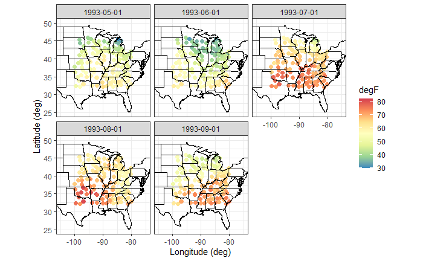

```r
ggplot(Tmin_long_loc_sub) + # plot points
  geom_point(aes(x = lon,y = lat, # lon and lat
                 colour = z), # attribute color
             size = 2) + # make all points larger
  col_scale(name = "degF") + # attach color scale
  xlab("Longitude (deg)") + # x-axis label
  ylab("Latitude (deg)") + # y-axis label
  geom_path(data = map_data("state"), # add US states map
            aes(x = long, y = lat, group = group)) +
 facet_wrap(~date) + # facet by time
  coord_quickmap(xlim = c(-105, -75),
              ylim = c(25, 50))+ # zoom in
  theme_bw() # B&W theme
```

In addition to minimum temperature, you may explore the spatiotemporal pattern of dew point and precipitation data.